# 2026-10-08_p8108_hw-01

Chris

2026-10-08

The author would like to acknowledge the use of ChatGPT, a language model developed by OpenAI, in the preparation of this assignment. ChatGPT was used in the following ways in this assignment: writing latex, debuggig codes and reading the provided paper.

https://github.com/ChrisW12372/2026-10-08_p8108_hw-01.git

```r
library(tidyverse)
library(survival)
```

# 1 Problem 1

## 1.1 question a

For both endpoints, the time origin is the date of bone marrow transplantation, and time is measured in months.

For the relapse endpoint, the event is the first relapse after transplantation. Set $\delta_{R} = 1$ if relapse is observed and $\delta_{R} = 0$ if a patient doesn’t relapse in the end. The observed time is the time to relapse or, for a censored patient, the time to the last follow-up.

For the death endpoint, the event is death after transplantation. Set $\delta_{D} = 1$ if death is observed and $\delta_{D} = 0$ if a patient is alive. The observed time is the time to death or, for a censored patient, the time to the last follow-up.

Patient 4 relapsed at month 20, so the relapse observation is $(t_R, \delta_{R}) = (20, 1)$, who was still alive at the end of month 33, meaning the death observation should be $(33, 0)$.

## 1.2 question b

Let $t_i$ be the observed time and $\delta_i$ indicate whether the event was observed. An observed event contributes $f(t_i)$ to the likelihood, while a right-censored observation contributes $S(t_i)$. For the exponential model,

$$f(t)=\lambda e^{-\lambda t},
\qquad
S(t)=e^{-\lambda t}.$$

Under independent patients and independent censoring, the event-time likelihood is

$$\begin{aligned}
L(\lambda)
&=\prod_{i=1}^{n}
f(t_i)^{\delta_i}S(t_i)^{1-\delta_i}\\
&=\prod_{i=1}^{n}
(\lambda e^{-\lambda t_i})^{\delta_i}
(e^{-\lambda t_i})^{1-\delta_i}\\
&=\lambda^d\exp\left(-\lambda\sum_{i=1}^{n}t_i\right),
\end{aligned}$$

where $d=\sum_{i=1}^{n}\delta_i$ is the number of observed events. Factors from the censoring distribution that do not depend on $\lambda$ are omitted.

The log-likelihood and its derivative are

$$\ell(\lambda)
=d\log\lambda-\lambda\sum_{i=1}^{n}t_i,
\qquad
\ell'(\lambda)
=\frac{d}{\lambda}-\sum_{i=1}^{n}t_i.$$

Setting the derivative to zero gives

$$\widehat{\lambda}
=\frac{d}{\sum_{i=1}^{n}t_i}.$$

Since $\ell''(\lambda)=-d/\lambda^2<0$, this estimate maximizes the likelihood.

For relapse, there are 6 observed events and 186 patient-months of observation:

$$\sum_{i=1}^{10}t_{Ri}
=5+8+12+20+32+27+16+17+19+30=186.$$

Thus,

$$\widehat{\lambda}_R
=\frac{6}{186}
=0.03226\ \text{month}^{-1}.$$

For death, there are 3 observed events and 223 patient-months of observation:

$$\sum_{i=1}^{10}t_{Di}
=8+12+15+33+45+28+16+17+19+30=223.$$

Thus,

$$\widehat{\lambda}_D
=\frac{3}{223}
=0.01345\ \text{month}^{-1}.$$

The estimated constant relapse hazard is 0.03226 per month among patients who have not yet relapsed. The estimated constant death hazard is 0.01345 per month among patients who are still alive. For a short interval of length $\Delta t$ months, the conditional probability of an event is approximately $\lambda\Delta t$.

## 1.3 question c

For an exponential model, the fitted mean, median, survival probability, and event probability are

$$\widehat{E(T)}=\frac{1}{\widehat{\lambda}},
\qquad
\widehat{m}=\frac{\log 2}{\widehat{\lambda}},$$

$$\widehat{S}(t)=e^{-\widehat{\lambda}t},
\qquad
\widehat{P}(T\leq t)=1-e^{-\widehat{\lambda}t}.$$

```r
lambda <- c(Relapse = 6 / 186, Death = 3 / 223)

results_prob1 <- tibble(
  Endpoint = names(lambda),
  Mean = 1 / lambda,
  Median = log(2) / lambda,
  S12 = exp(-12 * lambda),
  S24 = exp(-24 * lambda),
  Event12 = 1 - exp(-12 * lambda)
)

knitr::kable(
  results_prob1,
  digits = c(0, 2, 2, 4, 4, 4),
  col.names = c(
    "Endpoint", "Mean (months)", "Median (months)",
    "S(12)", "S(24)", "P(T ≤ 12)"
  ),
  row.names = FALSE
)
```

| Endpoint | Mean (months) | Median (months) | S(12) | S(24) | P(T ≤ 12) |
| --- | --- | --- | --- | --- | --- |
| Relapse | 31.00 | 21.49 | 0.6790 | 0.4611 | 0.3210 |
| Death | 74.33 | 51.52 | 0.8509 | 0.7241 | 0.1491 |

Under the fitted exponential models, the probability of remaining relapse free at 12 months after transplantation is approximately 67.9%, and the probability of being alive at 12 months is approximately 85.1%. Patients who have relapsed but remain alive are still counted as survivors for the death endpoint.

## 1.4 question d

Let $T_R$ be the time to relapse. Using the fitted relapse rate $\widehat{\lambda}_R=6/186$, we obtain

$$\begin{aligned}
P(T_R>24\mid T_R>12)
&=\frac{S_R(24)}{S_R(12)}\\
&=\frac{e^{-24\widehat{\lambda}_R}}
{e^{-12\widehat{\lambda}_R}}\\
&=e^{-12\widehat{\lambda}_R}\\
&=e^{-12(6/186)}
\approx 0.6790.
\end{aligned}$$

This equals the probability of remaining relapse free beyond month 12:

$$P(T_R>12)=e^{-12(6/186)}\approx 0.6790.$$

Thus, given no relapse through month 12, the fitted probability of remaining relapse free beyond month 24 is approximately 67.9%. This equality follows from the memoryless property of the exponential distribution.

## 1.5 question e

The Kaplan–Meier median time to relapse is 27 months: the estimated survival probability decreases from 0.525 at month 20 to 0.350 at month 27.

The Kaplan–Meier median time to death is not estimable because the survival curve remains above 0.5, with a final estimate of 0.7.

The exponential model assumes a constant hazard and extrapolates beyond the observed follow-up. Its survival curve reaches 0.5 at $\log(2)/\widehat{\lambda}$, giving a finite median time to death of 51.52 months.

# 2 Problem 2

## 2.1 question a

Let $T$ be the time in days from randomization to the first documented treatment response, defined as a CD4 count above 300 cells/mm$^3$.

$$S(t)=P(T>t)$$

is the probability that a patient has not yet responded by day $t$.

$$F(t)=P(T\leq t)=1-S(t)$$

is the probability that a patient has responded by day $t$.

A larger $S(t)$ indicates slower treatment response because more patients remain without a response. Here, “survival” means remaining free of the response event, rather than remaining alive.

## 2.2 question b

```r
df_prob2 <- tibble(
  time = c(22, 2, 48, 80, 160, 238, 56, 94, 51,
           12, 161, 80, 180, 4, 90, 180, 3),
  status = c(1, 1, 1, 1, 1, 1, 0, 0, 0,
             1, 1, 1, 1, 1, 1, 0, 1)
)

# status: 1 = response, 0 = right censoring
times <- sort(unique(df_prob2$time))

km_table_prob2 <- tibble(
  time = times,
  n_risk = sapply(times, function(t) sum(df_prob2$time >= t)),
  n_response = sapply(times, function(t) {
    sum(df_prob2$time == t & df_prob2$status == 1)
  }),
  n_censored = sapply(times, function(t) {
    sum(df_prob2$time == t & df_prob2$status == 0)
  })
)

km_table_prob2$factor <- with(km_table_prob2, 1 - n_response / n_risk)
km_table_prob2$survival <- cumprod(km_table_prob2$factor)

knitr::kable(
  km_table_prob2,
  digits = 4,
  col.names = c(
    "Time (days)", "At risk", "Responses", "Censored",
    "Conditional survival factor", "KM survival"
  ),
  row.names = FALSE
)
```

| Time (days) | At risk | Responses | Censored | Conditional survival factor | KM survival |
| --- | --- | --- | --- | --- | --- |
| 2 | 17 | 1 | 0 | 0.9412 | 0.9412 |
| 3 | 16 | 1 | 0 | 0.9375 | 0.8824 |
| 4 | 15 | 1 | 0 | 0.9333 | 0.8235 |
| 12 | 14 | 1 | 0 | 0.9286 | 0.7647 |
| 22 | 13 | 1 | 0 | 0.9231 | 0.7059 |
| 48 | 12 | 1 | 0 | 0.9167 | 0.6471 |
| 51 | 11 | 0 | 1 | 1.0000 | 0.6471 |
| 56 | 10 | 0 | 1 | 1.0000 | 0.6471 |
| 80 | 9 | 2 | 0 | 0.7778 | 0.5033 |
| 90 | 7 | 1 | 0 | 0.8571 | 0.4314 |
| 94 | 6 | 0 | 1 | 1.0000 | 0.4314 |
| 160 | 5 | 1 | 0 | 0.8000 | 0.3451 |
| 161 | 4 | 1 | 0 | 0.7500 | 0.2588 |
| 180 | 3 | 1 | 1 | 0.6667 | 0.1725 |
| 238 | 1 | 1 | 0 | 0.0000 | 0.0000 |

Starting with $\widehat{S}(0)=1$, the hand calculations through day 22 are

$$\begin{aligned}
\widehat{S}(2)
&=\frac{16}{17}=0.9412,\\
\widehat{S}(3)
&=\frac{16}{17}\times\frac{15}{16}
=\frac{15}{17}=0.8824,\\
\widehat{S}(4)
&=\frac{15}{17}\times\frac{14}{15}
=\frac{14}{17}=0.8235,\\
\widehat{S}(12)
&=\frac{14}{17}\times\frac{13}{14}
=\frac{13}{17}=0.7647,\\
\widehat{S}(22)
&=\frac{13}{17}\times\frac{12}{13}
=\frac{12}{17}=0.7059.
\end{aligned}$$

At day 80, there are 9 patients at risk and 2 responses:

$$1-\frac{d_{80}}{n_{80}}
=1-\frac{2}{9}=\frac{7}{9},
\qquad
\widehat{S}(80)
=\frac{11}{17}\times\frac{7}{9}
=0.5033.$$

At day 180, there are 3 patients at risk and 1 response. The patient censored that day is included in the risk set:

$$1-\frac{d_{180}}{n_{180}}
=1-\frac{1}{3}=\frac{2}{3},
\qquad
\widehat{S}(180)
=\frac{22}{85}\times\frac{2}{3}
=0.1725.$$

The estimated probabilities of not yet responding by days 22, 80, and 180 are 70.6%, 50.3%, and 17.3%, respectively. Censoring alone does not lower the curve because no response is observed; it only reduces later risk sets. At day 238, the last remaining patient responds, so the KM estimate falls to zero.

## 2.3 question c

```r
km_fit <- survfit(
  Surv(time, status) ~ 1,
  data = df_prob2,
  conf.int = 0.95,
  conf.type = "log-log"
)

# Compare the software estimates with the calculation table
km_summary <- summary(km_fit, censored = TRUE)

comparison <- data.frame(
  time = km_summary$time,
  manual = km_table_prob2$survival[
    match(km_summary$time, km_table_prob2$time)
  ],
  software = km_summary$surv
)

stopifnot(
  isTRUE(all.equal(
    comparison$manual,
    comparison$software,
    tolerance = 1e-10
  ))
)

knitr::kable(
  comparison,
  digits = 4,
  col.names = c("Time (days)", "Calculated KM", "Software KM"),
  row.names = FALSE
)
```

| Time (days) | Calculated KM | Software KM |
| --- | --- | --- |
| 2 | 0.9412 | 0.9412 |
| 3 | 0.8824 | 0.8824 |
| 4 | 0.8235 | 0.8235 |
| 12 | 0.7647 | 0.7647 |
| 22 | 0.7059 | 0.7059 |
| 48 | 0.6471 | 0.6471 |
| 51 | 0.6471 | 0.6471 |
| 56 | 0.6471 | 0.6471 |
| 80 | 0.5033 | 0.5033 |
| 90 | 0.4314 | 0.4314 |
| 94 | 0.4314 | 0.4314 |
| 160 | 0.3451 | 0.3451 |
| 161 | 0.2588 | 0.2588 |
| 180 | 0.1725 | 0.1725 |
| 238 | 0.0000 | 0.0000 |

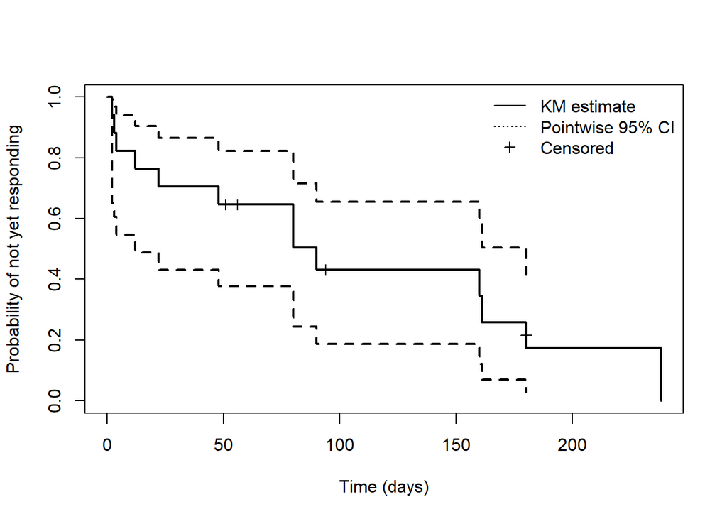

```r
plot(
  km_fit,
  conf.int = TRUE,
  mark.time = TRUE,
  xlab = "Time (days)",
  ylab = "Probability of not yet responding",
  ylim = c(0, 1),
  col = "black",
  lwd = 2
)

legend(
  "topright",
  legend = c("KM estimate", "Pointwise 95% CI", "Censored"),
  lty = c(1, 3, NA),
  pch = c(NA, NA, 3),
  col = "black",
  bty = "n"
)
```

The software KM estimates agree with the calculation table.

Pointwise 95% coverage means that, at a fixed time $t$, intervals constructed in this way would contain the true $S(t)$ in approximately 95% of repeated samples. It does not mean that the intervals cover the entire survival curve simultaneously with 95% probability.

## 2.4 question d

```r
# Greenwood calculations through day 90
gw <- subset(km_table_prob2, time <= 90)

gw$greenwood_sum <- cumsum(
  with(gw, n_response / (n_risk * (n_risk - n_response)))
)

gw$se <- gw$survival * sqrt(gw$greenwood_sum)

out <- subset(gw, time %in% c(2, 90))

# Raw linear intervals: no clipping
out$linear_lower <- out$survival - 1.96 * out$se
out$linear_upper <- out$survival + 1.96 * out$se

# Log-log intervals from the software fit in part (c)
ci <- summary(km_fit, times = out$time)

results <- data.frame(
  time = out$time,
  survival = out$survival,
  se = out$se,
  linear_lower = out$linear_lower,
  linear_upper = out$linear_upper,
  loglog_lower = ci$lower,
  loglog_upper = ci$upper
)

knitr::kable(
  results,
  digits = 4,
  col.names = c(
    "Day", "KM survival", "SE",
    "Linear lower", "Linear upper",
    "Log-log lower", "Log-log upper"
  ),
  row.names = FALSE
)
```

| Day | KM survival | SE | Linear lower | Linear upper | Log-log lower | Log-log upper |
| --- | --- | --- | --- | --- | --- | --- |
| 2 | 0.9412 | 0.0571 | 0.8293 | 1.0530 | 0.6502 | 0.9915 |
| 90 | 0.4314 | 0.1277 | 0.1811 | 0.6817 | 0.1870 | 0.6560 |

Greenwood’s formula gives

$$\operatorname{SE}\{\widehat{S}(t)\}
=\widehat{S}(t)
\sqrt{\sum_{t_j\leq t}\frac{d_j}{n_j(n_j-d_j)}}.$$

At day 2,

$$\operatorname{SE}\{\widehat{S}(2)\}
=\frac{16}{17}\sqrt{\frac{1}{17(16)}}
=0.05707.$$

At day 90, the Greenwood sum is

$$\begin{aligned}
G(90)
&=\frac{1}{17(16)}
+\frac{1}{16(15)}
+\frac{1}{15(14)}
+\frac{1}{14(13)}\\
&\quad+\frac{1}{13(12)}
+\frac{1}{12(11)}
+\frac{2}{9(7)}
+\frac{1}{7(6)}\\
&=0.087641.
\end{aligned}$$

Thus,

$$\operatorname{SE}\{\widehat{S}(90)\}
=\frac{22}{51}\sqrt{0.087641}
=0.12770.$$

The untruncated linear 95% confidence intervals are

$$\begin{aligned}
\text{Day 2:}\quad
&0.94118\pm1.96(0.05707)
=(0.8293,\ 1.0530),\\
\text{Day 90:}\quad
&0.43137\pm1.96(0.12770)
=(0.1811,\ 0.6817).
\end{aligned}$$

The day-2 linear upper bound exceeds 1. The log-log transformation keeps confidence limits within $[0,1]$ and allows asymmetric intervals. The linear intervals above were calculated directly without clipping; `survfit(conf.type = "plain")` clips its bounds to $[0,1]$.

## 2.5 question e

```r
# Survival immediately before each observed time
km_table_prob2$survival_before <- c(
  1, head(km_table_prob2$survival, -1)
)

probs <- c(0.25, 0.50, 0.75)

quantile_table <- do.call(rbind, lapply(probs, function(p) {
  i <- which(
    km_table_prob2$n_response > 0 &
      km_table_prob2$survival <= 1 - p
  )[1]

  data.frame(
    percentile = paste0(100 * p, "%"),
    threshold = 1 - p,
    time = km_table_prob2$time[i],
    survival_before = km_table_prob2$survival_before[i],
    survival_after = km_table_prob2$survival[i]
  )
}))

knitr::kable(
  quantile_table,
  digits = 4,
  col.names = c(
    "Percentile", "Threshold", "Time (days)",
    "Survival before", "Survival after"
  ),
  row.names = FALSE
)
```

| Percentile | Threshold | Time (days) | Survival before | Survival after |
| --- | --- | --- | --- | --- |
| 25% | 0.75 | 22 | 0.7647 | 0.7059 |
| 50% | 0.50 | 90 | 0.5033 | 0.4314 |
| 75% | 0.25 | 180 | 0.2588 | 0.1725 |

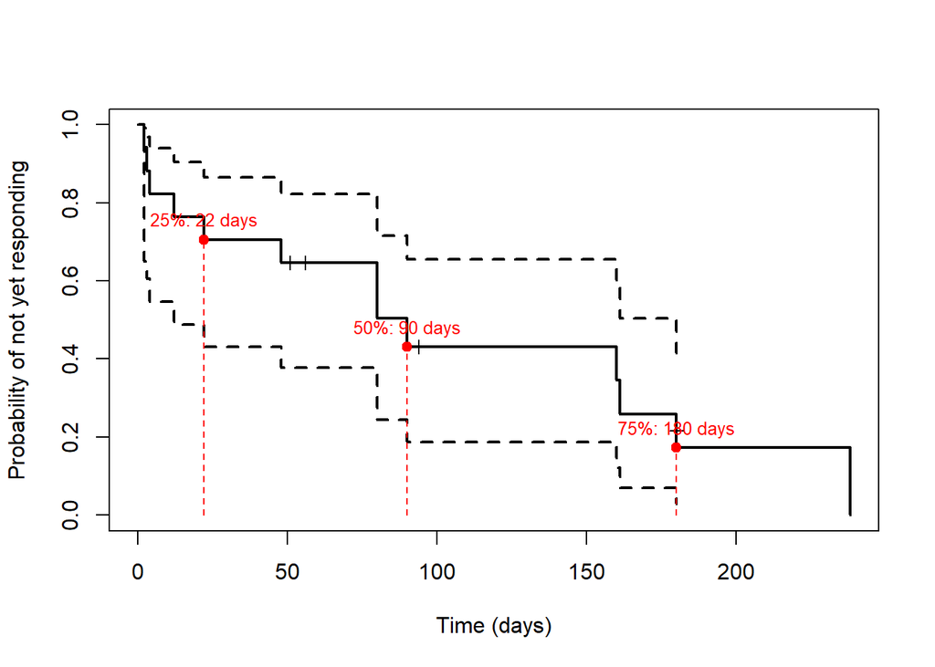

```r
plot(
  km_fit,
  conf.int = TRUE,
  mark.time = TRUE,
  xlab = "Time (days)",
  ylab = "Probability of not yet responding",
  ylim = c(0, 1),
  lwd = 2
)

points(
  quantile_table$time,
  quantile_table$survival_after,
  pch = 19,
  col = "red"
)

segments(
  x0 = quantile_table$time, y0 = 0,
  x1 = quantile_table$time,
  y1 = quantile_table$survival_after,
  lty = 2,
  col = "red"
)

text(
  quantile_table$time,
  quantile_table$survival_after,
  labels = paste0(
    quantile_table$percentile, ": ",
    quantile_table$time, " days"
  ),
  pos = 3,
  cex = 0.8,
  col = "red"
)
```

The estimated $p$th quantile is

$$\widehat{q}_p
=\min\{t_j:\widehat{S}(t_j)\leq 1-p\},$$

where $t_j$ ranges over event times. No interpolation is used.

The estimated 25th, 50th, and 75th percentiles are 22, 90, and 180 days, respectively. The median is 90 days: this is the first time at which the estimated probability of having responded reaches or exceeds 50%.

# 3 problem 3

## 3.1 question a

The Nelson–Aalen cumulative hazard and the Fleming–Harrington survival estimate are

$$\widehat{H}_{NA}(t)
=\sum_{t_j\leq t}\frac{d_j}{n_j},
\qquad
\widehat{S}_{FH}(t)
=\exp\{-\widehat{H}_{NA}(t)\}.$$

```r
# Keep distinct event times
na_table <- subset(
  km_table_prob2,
  n_response > 0,
  select = c(time, n_risk, n_response, survival)
)

na_table$increment <- with(na_table, n_response / n_risk)
na_table$cum_hazard <- cumsum(na_table$increment)
na_table$fh_survival <- exp(-na_table$cum_hazard)

knitr::kable(
  na_table[, c(
    "time", "n_risk", "n_response", "increment", "cum_hazard"
  )],
  digits = 4,
  col.names = c(
    "Day", "At risk", "Responses",
    "Hazard increment", "Cumulative hazard"
  ),
  row.names = FALSE
)
```

| Day | At risk | Responses | Hazard increment | Cumulative hazard |
| --- | --- | --- | --- | --- |
| 2 | 17 | 1 | 0.0588 | 0.0588 |
| 3 | 16 | 1 | 0.0625 | 0.1213 |
| 4 | 15 | 1 | 0.0667 | 0.1880 |
| 12 | 14 | 1 | 0.0714 | 0.2594 |
| 22 | 13 | 1 | 0.0769 | 0.3363 |
| 48 | 12 | 1 | 0.0833 | 0.4197 |
| 80 | 9 | 2 | 0.2222 | 0.6419 |
| 90 | 7 | 1 | 0.1429 | 0.7848 |
| 160 | 5 | 1 | 0.2000 | 0.9848 |
| 161 | 4 | 1 | 0.2500 | 1.2348 |
| 180 | 3 | 1 | 0.3333 | 1.5681 |
| 238 | 1 | 1 | 1.0000 | 2.5681 |

```r
comparison <- subset(
  na_table,
  time %in% c(90, 180, 238),
  select = c(time, survival, fh_survival)
)

knitr::kable(
  comparison,
  digits = 4,
  col.names = c("Day", "KM survival", "FH survival"),
  row.names = FALSE
)
```

| Day | KM survival | FH survival |
| --- | --- | --- |
| 90 | 0.4314 | 0.4562 |
| 180 | 0.1725 | 0.2084 |
| 238 | 0.0000 | 0.0767 |

At day 80, the two tied responses contribute $\frac{2}{9}$ to the cumulative hazard. At day 180, the risk set includes the patient censored that day, so the increment is $\frac{1}{3}$.

The FH estimates are higher than the KM estimates at all three comparison times. At day 238, KM falls to zero because the last patient responds. The FH estimate remains positive because the cumulative hazard is finite:

$$\widehat{S}_{FH}(238)
=e^{-2.5681}
\approx 0.0767.$$

## 3.2 question b

```r
hazard_comparison <- subset(
  na_table,
  time %in% c(90, 180, 238),
  select = c(time, cum_hazard, survival)
)

hazard_comparison$neg_log_km <- -log(hazard_comparison$survival)

knitr::kable(
  hazard_comparison[, c("time", "cum_hazard", "neg_log_km")],
  digits = 4,
  col.names = c("Day", "Nelson-Aalen", "Negative log KM"),
  row.names = FALSE
)
```

| Day | Nelson-Aalen | Negative log KM |
| --- | --- | --- |
| 90 | 0.7848 | 0.8408 |
| 180 | 1.5681 | 1.7571 |
| 238 | 2.5681 | Inf |

The negative log KM estimate is larger than the Nelson–Aalen estimate at both days 90 and 180. At day 238, the KM estimate is zero, so $-\log\widehat{S}_{KM}(238)=+\infty$, while the Nelson–Aalen estimate remains finite at 2.5681.

The two estimators use different increments:

$$\widehat{H}_{NA}(t)=\sum_{t_j\leq t}\frac{d_j}{n_j},
\qquad
-\log\widehat{S}_{KM}(t)
=\sum_{t_j\leq t}-\log\left(1-\frac{d_j}{n_j}\right).$$

Since $-\log(1-x)\approx x$ only when $x$ is small, the estimates can differ noticeably in this small sample, especially when few patients remain at risk.

## 3.3 question c

```r
lower <- seq(0, 210, by = 30)
upper <- lower + 30

life_table <- data.frame(
  interval = paste0("(", lower, ", ", upper, "]"),
  midpoint = lower + 15,
  n = sapply(lower, function(a) sum(df_prob2$time > a)),
  d = sapply(seq_along(lower), function(i) {
    sum(df_prob2$time > lower[i] & df_prob2$time <= upper[i] &
          df_prob2$status == 1)
  }),
  c = sapply(seq_along(lower), function(i) {
    sum(df_prob2$time > lower[i] & df_prob2$time <= upper[i] &
          df_prob2$status == 0)
  })
)

life_table$n_eff <- with(life_table, n - c / 2)
life_table$q <- with(life_table, d / n_eff)
life_table$survival <- cumprod(1 - life_table$q)

life_table$hazard <- with(
  life_table,
  d / (30 * (n - c / 2 - d / 2))
)

knitr::kable(
  life_table,
  digits = 4,
  col.names = c(
    "Interval", "Midpoint", "Starting risk set",
    "Responses", "Censored", "Effective risk set",
    "Response probability", "Endpoint survival", "Hazard"
  ),
  row.names = FALSE
)
```

| Interval | Midpoint | Starting risk set | Responses | Censored | Effective risk set | Response probability | Endpoint survival | Hazard |
| --- | --- | --- | --- | --- | --- | --- | --- | --- |
| (0, 30] | 15 | 17 | 5 | 0 | 17.0 | 0.2941 | 0.7059 | 0.0115 |
| (30, 60] | 45 | 12 | 1 | 2 | 11.0 | 0.0909 | 0.6417 | 0.0032 |
| (60, 90] | 75 | 9 | 3 | 0 | 9.0 | 0.3333 | 0.4278 | 0.0133 |
| (90, 120] | 105 | 6 | 0 | 1 | 5.5 | 0.0000 | 0.4278 | 0.0000 |
| (120, 150] | 135 | 5 | 0 | 0 | 5.0 | 0.0000 | 0.4278 | 0.0000 |
| (150, 180] | 165 | 5 | 3 | 1 | 4.5 | 0.6667 | 0.1426 | 0.0333 |
| (180, 210] | 195 | 1 | 0 | 0 | 1.0 | 0.0000 | 0.1426 | 0.0000 |
| (210, 240] | 225 | 1 | 1 | 0 | 1.0 | 1.0000 | 0.0000 | 0.0667 |

The grouped-data approximation assumes independent censoring that is uniformly distributed within each interval. Censored patients therefore contribute half an interval of follow-up on average.

For $(150,180]$, there are 5 patients at the start, 3 responses (at days 160, 161, and 180), and 1 censoring (at day 180). The effective risk set and conditional response probability are

$$n_{\mathrm{eff}}=5-\frac{1}{2}=4.5,
\qquad
\widehat{q}=\frac{3}{4.5}=\frac{2}{3}.$$

Survival at day 150 is

$$\widehat{S}(150)
=\left(1-\frac{5}{17}\right)
\left(1-\frac{1}{11}\right)
\left(1-\frac{3}{9}\right)
=\frac{80}{187}.$$

Thus, survival at day 180 is

$$\widehat{S}(180)
=\frac{80}{187}\left(1-\frac{2}{3}\right)
=\frac{80}{561}
\approx 0.1426.$$

The estimated hazard at the interval midpoint, day 165, is

$$\widehat{h}(165)
=\frac{3}{30\left(5-\frac{1}{2}-\frac{3}{2}\right)}
=\frac{3}{90}
=0.03333\ \text{day}^{-1}.$$

## 3.4 question d

```r
days <- c(90, 180)

comparison <- data.frame(
  day = days,
  actuarial = life_table$survival[match(days, upper)],
  km = km_table_prob2$survival[match(days, km_table_prob2$time)]
)

knitr::kable(
  comparison,
  digits = 4,
  col.names = c("Day", "Actuarial survival", "KM survival"),
  row.names = FALSE
)
```

| Day | Actuarial survival | KM survival |
| --- | --- | --- |
| 90 | 0.4278 | 0.4314 |
| 180 | 0.1426 | 0.1725 |

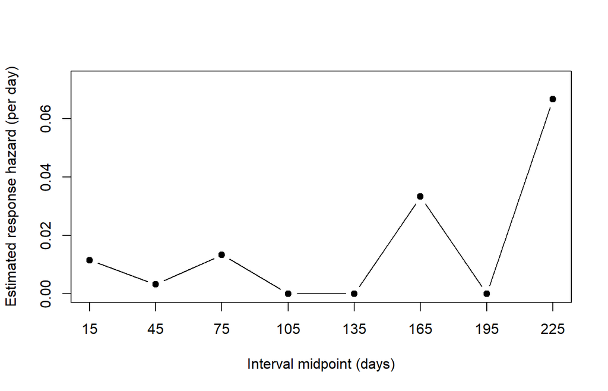

```r
plot(
  life_table$midpoint,
  life_table$hazard,
  type = "b",
  pch = 19,
  xlab = "Interval midpoint (days)",
  ylab = "Estimated response hazard (per day)",
  xaxt = "n",
  ylim = c(0, max(life_table$hazard) * 1.1)
)

axis(1, at = life_table$midpoint)
```

The actuarial estimates at days 90 and 180 are 0.4278 and 0.1426, compared with KM estimates of 0.4314 and 0.1725.

Grouping removes the exact ordering of responses and censoring. The actuarial method instead subtracts half the interval’s censoring count from the starting risk set, so its estimates differ from KM.

The estimated hazards vary across intervals, so the plot does not clearly support a constant-hazard exponential model. However, this variation is based on only 17 patients. Late intervals have very small risk sets, and the final hazard estimate is based on one patient. Zero-response intervals also do not imply a true hazard of zero. These estimates are unstable, so the plot alone is not enough to rule out an exponential model.

# 4 problem 4

## 4.1 question a

The time origin in Figure 2a is the first ablation procedure. In the mITT population, the event is the first documented episode of atrial fibrillation (AF) lasting more than 30 seconds after the 3-month blanking period, whether or not the patient uses antiarrhythmic drugs.

AF episodes during the first 3 months do not count as endpoint events. Therefore, the flat curve during this period reflects the endpoint definition; it does not show that no AF episodes occurred.

Here, “survival” means remaining free from a qualifying documented AF recurrence after one ablation procedure. It does not mean remaining alive or being free from all types of atrial arrhythmia.

## 4.2 question b

In the mITT population, the estimated probability of remaining free from qualifying AF recurrence at 12 months was 88% in the tailored arm and 70% in the anatomical arm.

The absolute difference was

$$\widehat{S}_{\text{tailored}}(12)
-\widehat{S}_{\text{anatomical}}(12)
=0.88-0.70=0.18.$$

Thus, the tailored arm had an estimated 18-percentage-point higher probability of remaining event free at 12 months.

The median time to the defined event was not reached in either arm. In Figure 2a, both Kaplan–Meier curves remain above 0.50 throughout follow-up, so neither median can be estimated within the observed period.

## 4.3 question c

The observed pairs, with time measured in months from the first ablation, are

$$(t_A,\delta_A)=(8,0), \qquad
(t_B,\delta_B)=(12,0).$$

Patient A is right-censored at the last event-free assessment because of loss to follow-up. Patient B is administratively right-censored at the end of follow-up.

Independent censoring requires that, within each treatment arm, patients censored at a given time have the same future event risk as patients still followed who are event free at that time.

Dropout driven by recurrent symptoms could violate this assumption because those symptoms may indicate AF recurrence. Patients who drop out could therefore have a higher event risk than those who remain under follow-up.

## 4.4 question d

Therefore, the trial does not justify the claim that AI-guided treatment prevents all atrial arrhythmias. The primary endpoint counts only AF, whereas the broader secondary endpoint also includes atrial flutter and atrial tachycardia. The results support improved freedom from documented AF recurrence, but do not demonstrate improved freedom from any atrial arrhythmia after one procedure.